# MPDW_ARCH

# ARCH-GARCH

## Uji sisaan Mean model

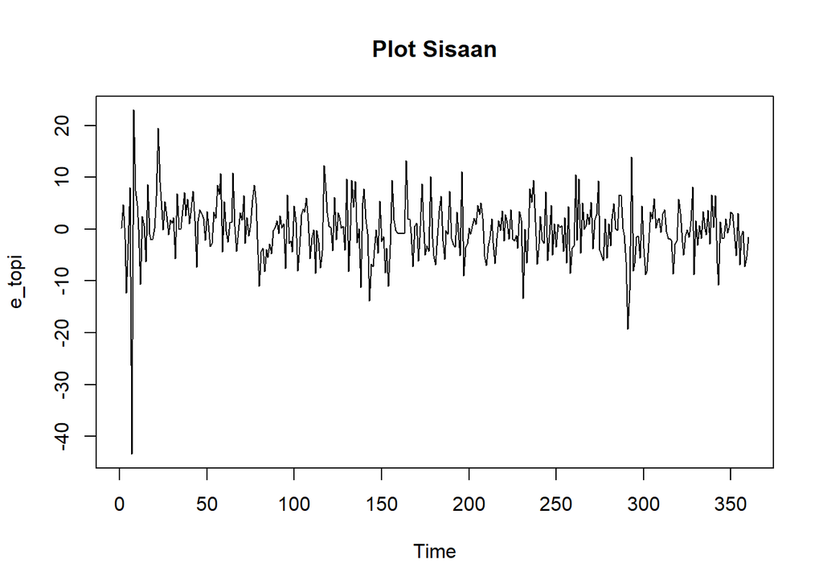

```r
sisaan <- model2.of$residuals
e_topi <- ts(sisaan)
plot.ts(e_topi, main = "Plot Sisaan")
```

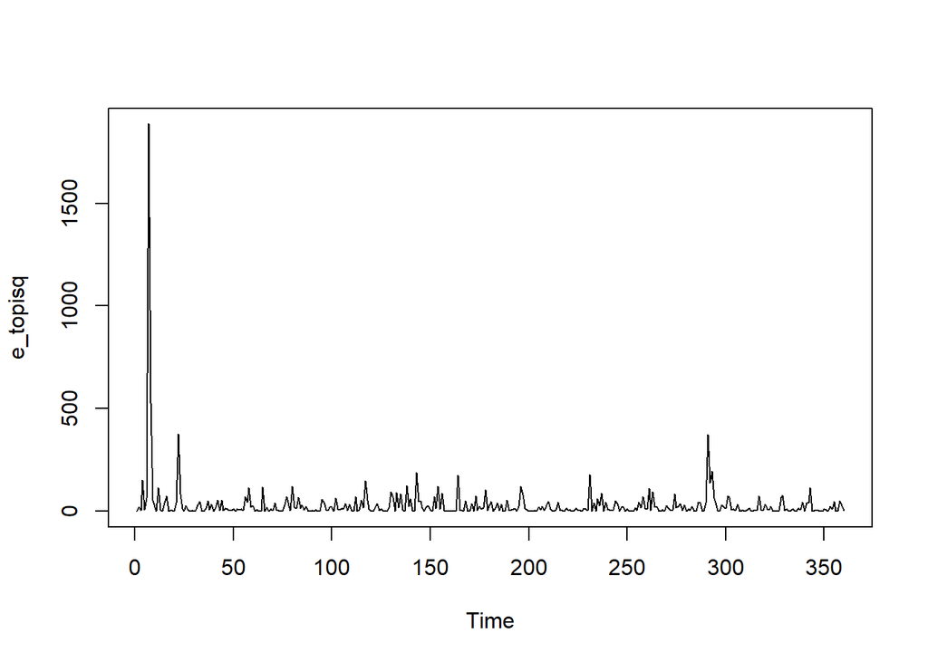

```r
e_topisq <- ts(sisaan^2)
plot.ts(e_topisq)
```

Sisaan belum memenuhi asumsi kehomogenan, berdasarkan plot.

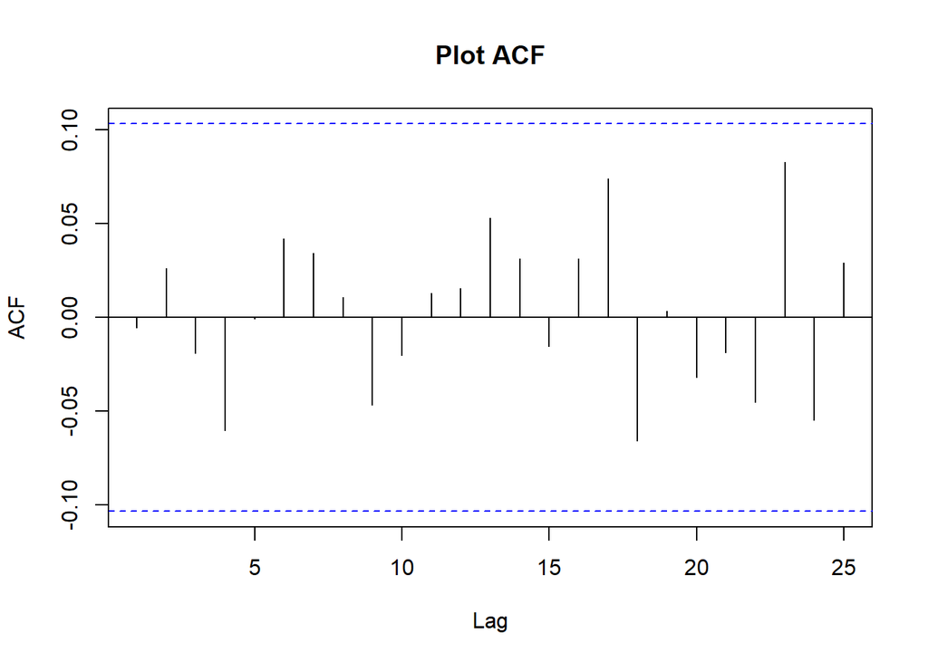

```r
acf(e_topi, main = "Plot ACF")
```

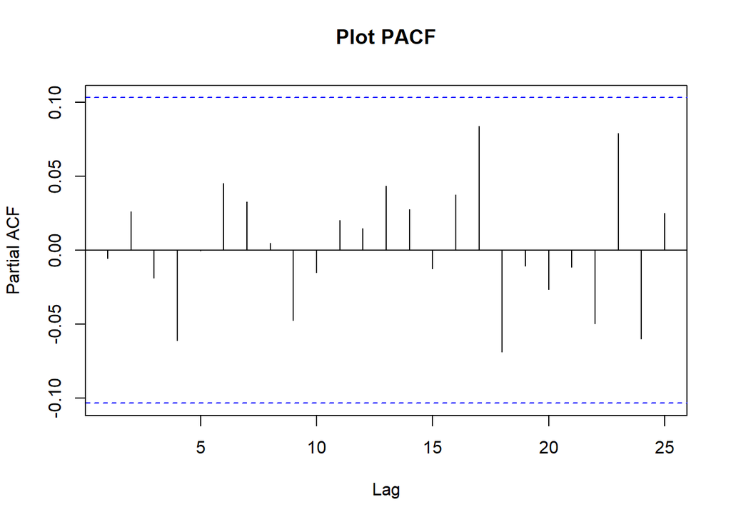

```r
pacf(e_topi, main = "Plot PACF")
```

Plot ACF serta PACF sisaan tidak menunjukkan adanya cut off pada lag tertentu, sehingga pemodelan ARIMA masih kurang tepat jika diterapkan pada data tinggi permukaan air yang digunakan

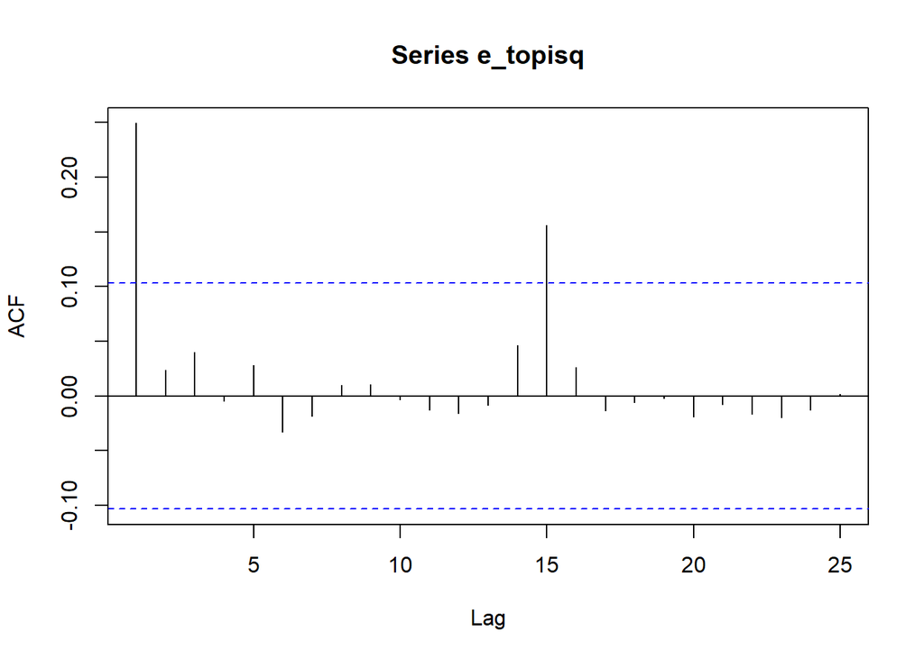

```r
acf(e_topisq)
```

# Uji Efek ARCH

Dapat dilakukan dengan uji Langrange Multiplier atau tes pengganda skor Berikut Hasil uji ARCH-LM untuk 10 lag pertama

```r
for (i in 1:10) {
  ArchTest <- ArchTest(sisaan.da, lags=i, demean=TRUE)
  cat("P Value LM Test lag ke", i,"adalah" , ArchTest$p.value, "\n") }
```

```
## P Value LM Test lag ke 1 adalah 1.774105e-06
## P Value LM Test lag ke 2 adalah 8.510331e-06
## P Value LM Test lag ke 3 adalah 2.519359e-05
## P Value LM Test lag ke 4 adalah 6.585651e-05
## P Value LM Test lag ke 5 adalah 0.0001338082
## P Value LM Test lag ke 6 adalah 0.0002093918
## P Value LM Test lag ke 7 adalah 2.572931e-19
## P Value LM Test lag ke 8 adalah 0.1382552
## P Value LM Test lag ke 9 adalah 0.04514649
## P Value LM Test lag ke 10 adalah 0.06104925
```

Dalam data deret waktu dikenal uji ARCH Langrange Multiplier atau ARCH-LM test, dengan hipotesisnya $H_0$: residual model tidak mengandung efek ARCH $H_1$: residual model mengandung efek ARCH

# Model ARCH-GARCH

```r
diff_train_data <- dif_ori
```

## Model GARCH

### GARCH(1,1)

```r
garchSpec11 <- ugarchspec(variance.model=list(model="sGARCH", garchOrder=c(1,1)),
                          mean.model=list(armaOrder=c(1,2)))
garchFit11 <- ugarchfit(spec=garchSpec11, data=diff_train_data)
coef(garchFit11)
```

```
##           mu          ar1          ma1          ma2        omega       alpha1
##  0.002194258  0.851775627 -1.171608749  0.191229924 11.414174353  0.249418749
##        beta1
##  0.418811649
```

```r
garchFit11 #AIC = 6.2782
```

```
##
## *---------------------------------*
## *          GARCH Model Fit        *
## *---------------------------------*
##
## Conditional Variance Dynamics
## -----------------------------------
## GARCH Model  : sGARCH(1,1)
## Mean Model   : ARFIMA(1,0,2)
## Distribution : norm
##
## Optimal Parameters
## ------------------------------------
##         Estimate  Std. Error     t value Pr(>|t|)
## mu      0.002194    0.037176  5.9024e-02 0.952933
## ar1     0.851776    0.032004  2.6615e+01 0.000000
## ma1    -1.171609    0.000152 -7.7005e+03 0.000000
## ma2     0.191230    0.002306  8.2914e+01 0.000000
## omega  11.414174    4.157914  2.7452e+00 0.006048
## alpha1  0.249419    0.096985  2.5717e+00 0.010120
## beta1   0.418812    0.162372  2.5793e+00 0.009899
##
## Robust Standard Errors:
##         Estimate  Std. Error     t value Pr(>|t|)
## mu      0.002194    0.033412  6.5672e-02 0.947639
## ar1     0.851776    0.037151  2.2928e+01 0.000000
## ma1    -1.171609    0.000213 -5.5039e+03 0.000000
## ma2     0.191230    0.002798  6.8343e+01 0.000000
## omega  11.414174    4.418351  2.5834e+00 0.009784
## alpha1  0.249419    0.234117  1.0654e+00 0.286712
## beta1   0.418812    0.190773  2.1953e+00 0.028139
##
## LogLikelihood : -1119.937
##
## Information Criteria
## ------------------------------------
##
## Akaike       6.2782
## Bayes        6.3539
## Shibata      6.2775
```

[output cut: 46 more lines]

```
## Negative Sign Bias  0.5126 0.6085
## Positive Sign Bias  0.7465 0.4559
## Joint Effect        0.9108 0.8228
##
##
## Adjusted Pearson Goodness-of-Fit Test:
## ------------------------------------
##   group statistic p-value(g-1)
## 1    20     28.80      0.06921
## 2    30     48.55      0.01288
## 3    40     49.58      0.11939
## 4    50     67.32      0.04219
##
##
## Elapsed time : 0.268826
```

```r
#Ada param nga signifikan, LM Test aman
```

### GARCH(1,2)

```r
garchSpec12 <- ugarchspec(variance.model=list(model="sGARCH", garchOrder=c(1,2)),
                          mean.model=list(armaOrder=c(1,2)))
garchFit12 <- ugarchfit(spec=garchSpec12, data=diff_train_data)
coef(garchFit12)
```

```
##            mu           ar1           ma1           ma2         omega
##  9.000256e-03  8.340367e-01 -1.167666e+00  1.905317e-01  1.088979e+01
##        alpha1         beta1         beta2
##  2.447548e-01  7.255017e-12  4.197294e-01
```

```r
garchFit12 #AIC=6.2646
```

```
##
## *---------------------------------*
## *          GARCH Model Fit        *
## *---------------------------------*
##
## Conditional Variance Dynamics
## -----------------------------------
## GARCH Model  : sGARCH(1,2)
## Mean Model   : ARFIMA(1,0,2)
## Distribution : norm
##
## Optimal Parameters
## ------------------------------------
##         Estimate  Std. Error     t value Pr(>|t|)
## mu       0.00900    0.036680     0.24538 0.806166
## ar1      0.83404    0.034898    23.89897 0.000000
## ma1     -1.16767    0.000121 -9674.84982 0.000000
## ma2      0.19053    0.002818    67.60529 0.000000
## omega   10.88979    5.080781     2.14333 0.032087
## alpha1   0.24476    0.120041     2.03892 0.041457
## beta1    0.00000    0.232331     0.00000 1.000000
## beta2    0.41973    0.312700     1.34227 0.179507
##
## Robust Standard Errors:
##         Estimate  Std. Error     t value Pr(>|t|)
## mu       0.00900    0.037342     0.24102  0.80954
## ar1      0.83404    0.048222    17.29574  0.00000
## ma1     -1.16767    0.000220 -5305.69826  0.00000
## ma2      0.19053    0.003188    59.76595  0.00000
## omega   10.88979    6.941578     1.56878  0.11670
## alpha1   0.24476    0.254009     0.96357  0.33526
## beta1    0.00000    0.636765     0.00000  1.00000
## beta2    0.41973    0.792902     0.52936  0.59656
##
## LogLikelihood : -1116.5
##
## Information Criteria
## ------------------------------------
##
## Akaike       6.2646
```

[output cut: 49 more lines]

```
## Negative Sign Bias  0.4842 0.6285
## Positive Sign Bias  0.5982 0.5501
## Joint Effect        0.6271 0.8902
##
##
## Adjusted Pearson Goodness-of-Fit Test:
## ------------------------------------
##   group statistic p-value(g-1)
## 1    20     25.57      0.14268
## 2    30     34.51      0.22109
## 3    40     51.58      0.08549
## 4    50     44.48      0.65663
##
##
## Elapsed time : 0.304914
```

```r
#Ada param nga signifikan, LM Test aman
```

### GARCH(2,1)

```r
garchSpec21 <- ugarchspec(variance.model=list(model="sGARCH", garchOrder=c(2,1)),
                          mean.model=list(armaOrder=c(1,2)))
garchFit21 <- ugarchfit(spec=garchSpec21, data=diff_train_data)
coef(garchFit21)
```

```
##            mu           ar1           ma1           ma2         omega
##  2.197510e-03  8.517759e-01 -1.171610e+00  1.912307e-01  1.141292e+01
##        alpha1        alpha2         beta1
##  2.494072e-01  2.928793e-09  4.188588e-01
```

```r
garchFit21 #AIC=6.2838
```

```
##
## *---------------------------------*
## *          GARCH Model Fit        *
## *---------------------------------*
##
## Conditional Variance Dynamics
## -----------------------------------
## GARCH Model  : sGARCH(2,1)
## Mean Model   : ARFIMA(1,0,2)
## Distribution : norm
##
## Optimal Parameters
## ------------------------------------
##         Estimate  Std. Error     t value Pr(>|t|)
## mu      0.002198    0.037190  5.9088e-02 0.952882
## ar1     0.851776    0.032071  2.6559e+01 0.000000
## ma1    -1.171610    0.000151 -7.7405e+03 0.000000
## ma2     0.191231    0.002310  8.2785e+01 0.000000
## omega  11.412917    4.406962  2.5897e+00 0.009605
## alpha1  0.249407    0.104920  2.3771e+00 0.017449
## alpha2  0.000000    0.109548  0.0000e+00 1.000000
## beta1   0.418859    0.189085  2.2152e+00 0.026747
##
## Robust Standard Errors:
##         Estimate  Std. Error     t value Pr(>|t|)
## mu      0.002198    0.033291     0.06601 0.947370
## ar1     0.851776    0.038313    22.23226 0.000000
## ma1    -1.171610    0.000214 -5465.51191 0.000000
## ma2     0.191231    0.002765    69.17029 0.000000
## omega  11.412917    3.429158     3.32820 0.000874
## alpha1  0.249407    0.258400     0.96520 0.334445
## alpha2  0.000000    0.124540     0.00000 1.000000
## beta1   0.418859    0.124237     3.37145 0.000748
##
## LogLikelihood : -1119.937
##
## Information Criteria
## ------------------------------------
##
## Akaike       6.2838
```

[output cut: 49 more lines]

```
## Negative Sign Bias  0.5126 0.6085
## Positive Sign Bias  0.7465 0.4559
## Joint Effect        0.9108 0.8228
##
##
## Adjusted Pearson Goodness-of-Fit Test:
## ------------------------------------
##   group statistic p-value(g-1)
## 1    20     28.80      0.06921
## 2    30     48.55      0.01288
## 3    40     49.58      0.11939
## 4    50     67.32      0.04219
##
##
## Elapsed time : 0.302963
```

```r
#Ada param nga signifikan, LM Test aman
```

### GARCH(3,1)

```r
garchSpec31 <- ugarchspec(variance.model=list(model="sGARCH", garchOrder=c(3,1)),
                          mean.model=list(armaOrder=c(1,2)))
garchFit31 <- ugarchfit(spec=garchSpec31, data=diff_train_data)
coef(garchFit31)
```

```
##          mu         ar1         ma1         ma2       omega      alpha1
##  0.02745068  0.83801087 -1.19449904  0.21889600 18.03338004  0.17066425
##      alpha2      alpha3       beta1
##  0.03957328  0.24399408  0.01545878
```

```r
garchFit31 #AIC=6.2602
```

```
##
## *---------------------------------*
## *          GARCH Model Fit        *
## *---------------------------------*
##
## Conditional Variance Dynamics
## -----------------------------------
## GARCH Model  : sGARCH(3,1)
## Mean Model   : ARFIMA(1,0,2)
## Distribution : norm
##
## Optimal Parameters
## ------------------------------------
##         Estimate  Std. Error     t value Pr(>|t|)
## mu      0.027451    0.038497     0.71306 0.475810
## ar1     0.838011    0.030421    27.54730 0.000000
## ma1    -1.194499    0.000120 -9945.58579 0.000000
## ma2     0.218896    0.002381    91.94477 0.000000
## omega  18.033380    4.550101     3.96329 0.000074
## alpha1  0.170664    0.088258     1.93370 0.053150
## alpha2  0.039573    0.060689     0.65206 0.514361
## alpha3  0.243994    0.084722     2.87995 0.003977
## beta1   0.015459    0.147202     0.10502 0.916362
##
## Robust Standard Errors:
##         Estimate  Std. Error     t value Pr(>|t|)
## mu      0.027451    0.036792     0.74611 0.455600
## ar1     0.838011    0.027439    30.54044 0.000000
## ma1    -1.194499    0.000185 -6448.74162 0.000000
## ma2     0.218896    0.002204    99.29579 0.000000
## omega  18.033380    5.178815     3.48214 0.000497
## alpha1  0.170664    0.122989     1.38763 0.165249
## alpha2  0.039573    0.062196     0.63627 0.524602
## alpha3  0.243994    0.202618     1.20421 0.228508
## beta1   0.015459    0.150092     0.10300 0.917967
##
## LogLikelihood : -1114.707
##
## Information Criteria
## ------------------------------------
```

[output cut: 52 more lines]

```
## Negative Sign Bias  0.1347 0.8929
## Positive Sign Bias  0.4239 0.6719
## Joint Effect        0.2548 0.9683
##
##
## Adjusted Pearson Goodness-of-Fit Test:
## ------------------------------------
##   group statistic p-value(g-1)
## 1    20     25.12      0.15655
## 2    30     33.67      0.25139
## 3    40     54.04      0.05523
## 4    50     57.57      0.18763
##
##
## Elapsed time : 0.6344821
```

```r
#Ada param nga signifikan, LM Test aman
```

Karena dari beberapa trial GARCH ada parameter yang tidak signifikan, sudah dicoba sampai GARCH(6,1) serta beberapa kombinasinya. Maka akan dicoba model yang lebih sederhana dengan efek ARCH.